# Bellabeat Data Analytics Case study

## Introduction

Bellabeat is a small tech company that has high hopes of becoming a more successful company. They have several smart products aimed exclusively at women, including a wellness tracker (Leaf), a smartwatch (Time), a smart bottle (Spring), and a smart wellness app (BellaBeat app).

## 1. Ask

**Business Task** As a part of their business strategy, Bellabeat has tasked their marketing analytics team with conducting open source data analysis on other well-being smart devices in order to gain insights and apply them to the company’s goals for future growth. The stakeholders of Bellabeat hope that these insights will be used to inform future marketing decisions and shape the direction of the company in order to capture a larger share of the market.

To guide their research, the marketing analytics team has identified three key questions:

1. What are some trends in smart device usage?
2. How could these trends apply to Bellabeat customers?
3. How could these trends help influence Bellabeat’s marketing strategy?

#### 1.1 Key Stakeholders:

· **Urška Sršen** — Bellabeat’s cofounder and Chief Creative Officer

· **Sando Mur** — Mathematician and Bellabeat’s cofounder; key member of the Bellabeat executive team

· **Bellabeat marketing analytics team** — A team of data analysts responsible for collecting, analyzing, and reporting data that helps guide Bellabeat’s marketing strategy.

## 2 Prepare

#### 2.1 introduction to the data used

For this project, we will be using open source data from the FitBit Fitness Tracker Data set available on Kaggle (CC0: Public Domain, dataset made available through Mobius). This dataset contains personal fitness tracker data from thirty Fitbit users who consented to the submission of their minute-level output for physical activity, heart rate, and sleep monitoring. It includes information about daily activity, steps, and heart rate that can be used to explore users’ habits.

Before using this data, it is important that we conduct a full check on its reliability and validity through a ROCCC analysis. It is worth noting that this dataset has **a small sample size**, so caution should be taken when drawing strong conclusions from the data. The data is stored in a **safe location** and is in **wide format**.

Since Sršen is looking to gain insights form other data, we will be using [FitBit Fitness Tracker Data](http://https://www.kaggle.com/datasets/arashnic/fitbit)

(CC0: Public Domain, dataset made available through [Mobius](http://https://www.kaggle.com/arashnic)

#### 2.2 Fitbit Tracker Data ROCCC Analysis

In order to assess the reliability and suitability of the Fitbit Fitness Tracker data for our analysis, we will conduct a ROCCC analysis. This analysis includes the following factors:

**Reliability** Low. The dataset includes data from only 30 participants, which could potentially introduce a sample size bias.

**Originality** Low. This dataset was generated through a distributed survey conducted by Amazon Mechanical Turk in 2016, and the results must be taken with caution as it is a third-party data source.

**Comprehensiveness** Medium. While the dataset includes a variety of information about daily activity, steps, and heart rate, the sample size of 30 participants is not representative of a larger population. Additionally, the dataset does not specify the gender or age of the participants, which limits our ability to draw specific conclusions about Bellabeat’s customer base. It also does not include information about hydration or water intake, which means we cannot focus on the smart water bottle product. Some of the datasets also have less than 30 participants, which could potentially impact the validity of the data.

**Current** Low. The dataset is based on historical data from 2016, so it is possible that trends have changed in the past six years.

**Cited** High The dataset was created by four authors: Furberg Robert, Brinton Julia, Keating Michael, and Ortiz Alexa, and it is well-documented and correctly cited.

#### 2.3 Exploring the datasets

After initial exploration of the datasets, I have identified 18 csv files.

[figure not shown]

For this study, I will focus on the following files that contain daily data: * dailyActivity_merged.csv * dailyIntensities_merged.csv * dailySteps_merged.csv * sleepDay_merged.csv * weightLogInfo_merged.csv

I will drop any data or files that are not useful for my analysis.

#### 2.4 Installing libraries

```r
##Adding relevant libraries
library(tidyverse)
```

```r
library(skimr)
library(dplyr)
library(ggplot2)
library(lubridate)
library(plotly)
library(knitr)
library(reshape2)
```

#### 2.4 Importing datasets into R

```r
daily_activity <- read.csv("/Users/paul/Downloads/dailyActivity_merged.csv")
daily_steps <- read.csv("/Users/paul/Downloads/dailySteps_merged.csv")
daily_inten <- read.csv("/Users/paul/Downloads/dailyIntensities_merged.csv")
sleep_day <- read.csv("/Users/paul/Downloads/sleepDay_merged.csv")
weight_log <- read.csv("/Users/paul/Downloads/weightLogInfo_merged.csv")
```

## 3 Process

#### 3.1 Viewing the datasets

Before we begin our analysis, it is important to take a quick look at the data to check for any abnormalities. I have manually checked the csv files with Excel and made minor amendments to them, including splitting the time and date and reformatting columns as either date or string.

```r
head(sleep_day, 3)
```

```
##           Id              SleepDay TotalSleepRecords TotalMinutesAsleep
## 1 1503960366 4/12/2016 12:00:00 AM                 1                327
## 2 1503960366 4/13/2016 12:00:00 AM                 2                384
## 3 1503960366 4/15/2016 12:00:00 AM                 1                412
##   TotalTimeInBed
## 1            346
## 2            407
## 3            442
```

```r
head(daily_activity,3 )
```

```
##           Id ActivityDate TotalSteps TotalDistance TrackerDistance
## 1 1503960366    4/12/2016      13162          8.50            8.50
## 2 1503960366    4/13/2016      10735          6.97            6.97
## 3 1503960366    4/14/2016      10460          6.74            6.74
##   LoggedActivitiesDistance VeryActiveDistance ModeratelyActiveDistance
## 1                        0               1.88                     0.55
## 2                        0               1.57                     0.69
## 3                        0               2.44                     0.40
##   LightActiveDistance SedentaryActiveDistance VeryActiveMinutes
## 1                6.06                       0                25
## 2                4.71                       0                21
## 3                3.91                       0                30
##   FairlyActiveMinutes LightlyActiveMinutes SedentaryMinutes Calories
## 1                  13                  328              728     1985
## 2                  19                  217              776     1797
## 3                  11                  181             1218     1776
```

```r
head(daily_steps, 3)
```

```
##           Id ActivityDay StepTotal
## 1 1503960366   4/12/2016     13162
## 2 1503960366   4/13/2016     10735
## 3 1503960366   4/14/2016     10460
```

```r
head(weight_log, 3)
```

```
##           Id                 Date WeightKg WeightPounds Fat   BMI
## 1 1503960366 5/2/2016 11:59:59 PM     52.6     115.9631  22 22.65
## 2 1503960366 5/3/2016 11:59:59 PM     52.6     115.9631  NA 22.65
## 3 1927972279 4/13/2016 1:08:52 AM    133.5     294.3171  NA 47.54
##   IsManualReport        LogId
## 1           True 1.462234e+12
## 2           True 1.462320e+12
## 3          False 1.460510e+12
```

```r
head(daily_inten, 3)
```

```
##           Id ActivityDay SedentaryMinutes LightlyActiveMinutes
## 1 1503960366   4/12/2016              728                  328
## 2 1503960366   4/13/2016              776                  217
## 3 1503960366   4/14/2016             1218                  181
##   FairlyActiveMinutes VeryActiveMinutes SedentaryActiveDistance
## 1                  13                25                       0
## 2                  19                21                       0
## 3                  11                30                       0
##   LightActiveDistance ModeratelyActiveDistance VeryActiveDistance
## 1                6.06                     0.55               1.88
## 2                4.71                     0.69               1.57
## 3                3.91                     0.40               2.44
```

#### 3.2 Checking the population samples of each dataset for validity

Here we count the unique users to make sure they roughly equate to the toal number of participants.

```r
count(sleep_day,c(Id)) ## [24]
```

```
##         c(Id)  n
## 1  1503960366 25
## 2  1644430081  4
## 3  1844505072  3
## 4  1927972279  5
## 5  2026352035 28
## 6  2320127002  1
## 7  2347167796 15
## 8  3977333714 28
## 9  4020332650  8
## 10 4319703577 26
## 11 4388161847 24
## 12 4445114986 28
## 13 4558609924  5
## 14 4702921684 28
## 15 5553957443 31
## 16 5577150313 26
## 17 6117666160 18
## 18 6775888955  3
## 19 6962181067 31
## 20 7007744171  2
## 21 7086361926 24
## 22 8053475328  3
## 23 8378563200 32
## 24 8792009665 15
```

```r
count(daily_activity,c(Id)) ## [33]
```

```
##         c(Id)  n
## 1  1503960366 31
## 2  1624580081 31
## 3  1644430081 30
## 4  1844505072 31
## 5  1927972279 31
## 6  2022484408 31
## 7  2026352035 31
## 8  2320127002 31
## 9  2347167796 18
## 10 2873212765 31
## 11 3372868164 20
## 12 3977333714 30
## 13 4020332650 31
## 14 4057192912  4
```

[output cut: 19 more lines]

```r
count(daily_steps,c(Id)) ## [33]
```

```
##         c(Id)  n
## 1  1503960366 31
## 2  1624580081 31
## 3  1644430081 30
## 4  1844505072 31
## 5  1927972279 31
## 6  2022484408 31
## 7  2026352035 31
## 8  2320127002 31
## 9  2347167796 18
## 10 2873212765 31
## 11 3372868164 20
## 12 3977333714 30
## 13 4020332650 31
## 14 4057192912  4
```

[output cut: 19 more lines]

```r
count(weight_log,c(Id)) ## [8]
```

```
##        c(Id)  n
## 1 1503960366  2
## 2 1927972279  1
## 3 2873212765  2
## 4 4319703577  2
## 5 4558609924  5
## 6 5577150313  1
## 7 6962181067 30
## 8 8877689391 24
```

```r
count(daily_inten,c(Id)) ## [33]
```

```
##         c(Id)  n
## 1  1503960366 31
## 2  1624580081 31
## 3  1644430081 30
## 4  1844505072 31
## 5  1927972279 31
## 6  2022484408 31
## 7  2026352035 31
## 8  2320127002 31
## 9  2347167796 18
## 10 2873212765 31
## 11 3372868164 20
## 12 3977333714 30
## 13 4020332650 31
## 14 4057192912  4
```

[output cut: 19 more lines]

```r
glimpse(sleep_day)
```

```
## Rows: 413
## Columns: 5
## $ Id                 <dbl> 1503960366, 1503960366, 1503960366, 1503960366, 150…
## $ SleepDay           <chr> "4/12/2016 12:00:00 AM", "4/13/2016 12:00:00 AM", "…
## $ TotalSleepRecords  <int> 1, 2, 1, 2, 1, 1, 1, 1, 1, 1, 1, 1, 1, 1, 1, 1, 1, …
## $ TotalMinutesAsleep <int> 327, 384, 412, 340, 700, 304, 360, 325, 361, 430, 2…
## $ TotalTimeInBed     <int> 346, 407, 442, 367, 712, 320, 377, 364, 384, 449, 3…
```

```r
glimpse(daily_activity)
```

```
## Rows: 940
## Columns: 15
## $ Id                       <dbl> 1503960366, 1503960366, 1503960366, 150396036…
## $ ActivityDate             <chr> "4/12/2016", "4/13/2016", "4/14/2016", "4/15/…
## $ TotalSteps               <int> 13162, 10735, 10460, 9762, 12669, 9705, 13019…
## $ TotalDistance            <dbl> 8.50, 6.97, 6.74, 6.28, 8.16, 6.48, 8.59, 9.8…
## $ TrackerDistance          <dbl> 8.50, 6.97, 6.74, 6.28, 8.16, 6.48, 8.59, 9.8…
## $ LoggedActivitiesDistance <dbl> 0, 0, 0, 0, 0, 0, 0, 0, 0, 0, 0, 0, 0, 0, 0, …
## $ VeryActiveDistance       <dbl> 1.88, 1.57, 2.44, 2.14, 2.71, 3.19, 3.25, 3.5…
## $ ModeratelyActiveDistance <dbl> 0.55, 0.69, 0.40, 1.26, 0.41, 0.78, 0.64, 1.3…
## $ LightActiveDistance      <dbl> 6.06, 4.71, 3.91, 2.83, 5.04, 2.51, 4.71, 5.0…
## $ SedentaryActiveDistance  <dbl> 0, 0, 0, 0, 0, 0, 0, 0, 0, 0, 0, 0, 0, 0, 0, …
## $ VeryActiveMinutes        <int> 25, 21, 30, 29, 36, 38, 42, 50, 28, 19, 66, 4…
## $ FairlyActiveMinutes      <int> 13, 19, 11, 34, 10, 20, 16, 31, 12, 8, 27, 21…
## $ LightlyActiveMinutes     <int> 328, 217, 181, 209, 221, 164, 233, 264, 205, …
## $ SedentaryMinutes         <int> 728, 776, 1218, 726, 773, 539, 1149, 775, 818…
## $ Calories                 <int> 1985, 1797, 1776, 1745, 1863, 1728, 1921, 203…
```

```r
glimpse(daily_steps)
```

```
## Rows: 940
## Columns: 3
## $ Id          <dbl> 1503960366, 1503960366, 1503960366, 1503960366, 1503960366…
## $ ActivityDay <chr> "4/12/2016", "4/13/2016", "4/14/2016", "4/15/2016", "4/16/…
## $ StepTotal   <int> 13162, 10735, 10460, 9762, 12669, 9705, 13019, 15506, 1054…
```

```r
glimpse(daily_inten)
```

```
## Rows: 940
## Columns: 10
## $ Id                       <dbl> 1503960366, 1503960366, 1503960366, 150396036…
## $ ActivityDay              <chr> "4/12/2016", "4/13/2016", "4/14/2016", "4/15/…
## $ SedentaryMinutes         <int> 728, 776, 1218, 726, 773, 539, 1149, 775, 818…
## $ LightlyActiveMinutes     <int> 328, 217, 181, 209, 221, 164, 233, 264, 205, …
## $ FairlyActiveMinutes      <int> 13, 19, 11, 34, 10, 20, 16, 31, 12, 8, 27, 21…
## $ VeryActiveMinutes        <int> 25, 21, 30, 29, 36, 38, 42, 50, 28, 19, 66, 4…
## $ SedentaryActiveDistance  <dbl> 0, 0, 0, 0, 0, 0, 0, 0, 0, 0, 0, 0, 0, 0, 0, …
## $ LightActiveDistance      <dbl> 6.06, 4.71, 3.91, 2.83, 5.04, 2.51, 4.71, 5.0…
## $ ModeratelyActiveDistance <dbl> 0.55, 0.69, 0.40, 1.26, 0.41, 0.78, 0.64, 1.3…
## $ VeryActiveDistance       <dbl> 1.88, 1.57, 2.44, 2.14, 2.71, 3.19, 3.25, 3.5…
```

#### 3.4 Check for duplicates

```r
any(duplicated(sleep_day))
```

```
## [1] TRUE
```

```r
any(duplicated(daily_activity))
```

```
## [1] FALSE
```

```r
any(duplicated(daily_steps))
```

```
## [1] FALSE
```

```r
any(duplicated(daily_inten))
```

```
## [1] FALSE
```

Remove duplicates from sleep_day

```r
sleep_day_unique <- unique(sleep_day)
```

#### 3.5 Converting date foramts

```r
daily_activity$ActivityDate <- as.Date(daily_activity$ActivityDate, format = "%m/%d/%Y")
sleep_day_unique$SleepDay <- as.Date(sleep_day_unique$SleepDay, format = "%m/%d/%Y %I:%M:%S %p")
daily_steps$ActivityDay <- as.Date(daily_steps$ActivityDay, format = "%m/%d/%Y")
daily_inten$ActivityDay <- as.Date(daily_inten$ActivityDay, format = "%m/%d/%Y")

str(daily_activity)
```

```
## 'data.frame':    940 obs. of  15 variables:
##  $ Id                      : num  1.5e+09 1.5e+09 1.5e+09 1.5e+09 1.5e+09 ...
##  $ ActivityDate            : Date, format: "2016-04-12" "2016-04-13" ...
##  $ TotalSteps              : int  13162 10735 10460 9762 12669 9705 13019 15506 10544 9819 ...
##  $ TotalDistance           : num  8.5 6.97 6.74 6.28 8.16 ...
##  $ TrackerDistance         : num  8.5 6.97 6.74 6.28 8.16 ...
##  $ LoggedActivitiesDistance: num  0 0 0 0 0 0 0 0 0 0 ...
##  $ VeryActiveDistance      : num  1.88 1.57 2.44 2.14 2.71 ...
##  $ ModeratelyActiveDistance: num  0.55 0.69 0.4 1.26 0.41 ...
##  $ LightActiveDistance     : num  6.06 4.71 3.91 2.83 5.04 ...
##  $ SedentaryActiveDistance : num  0 0 0 0 0 0 0 0 0 0 ...
##  $ VeryActiveMinutes       : int  25 21 30 29 36 38 42 50 28 19 ...
##  $ FairlyActiveMinutes     : int  13 19 11 34 10 20 16 31 12 8 ...
##  $ LightlyActiveMinutes    : int  328 217 181 209 221 164 233 264 205 211 ...
##  $ SedentaryMinutes        : int  728 776 1218 726 773 539 1149 775 818 838 ...
##  $ Calories                : int  1985 1797 1776 1745 1863 1728 1921 2035 1786 1775 ...
```

```r
str(sleep_day_unique)
```

```
## 'data.frame':    410 obs. of  5 variables:
##  $ Id                : num  1.5e+09 1.5e+09 1.5e+09 1.5e+09 1.5e+09 ...
##  $ SleepDay          : Date, format: "2016-04-12" "2016-04-13" ...
##  $ TotalSleepRecords : int  1 2 1 2 1 1 1 1 1 1 ...
##  $ TotalMinutesAsleep: int  327 384 412 340 700 304 360 325 361 430 ...
##  $ TotalTimeInBed    : int  346 407 442 367 712 320 377 364 384 449 ...
```

```r
str(daily_steps)
```

```
## 'data.frame':    940 obs. of  3 variables:
##  $ Id         : num  1.5e+09 1.5e+09 1.5e+09 1.5e+09 1.5e+09 ...
##  $ ActivityDay: Date, format: "2016-04-12" "2016-04-13" ...
##  $ StepTotal  : int  13162 10735 10460 9762 12669 9705 13019 15506 10544 9819 ...
```

```r
str(daily_inten)
```

```
## 'data.frame':    940 obs. of  10 variables:
##  $ Id                      : num  1.5e+09 1.5e+09 1.5e+09 1.5e+09 1.5e+09 ...
##  $ ActivityDay             : Date, format: "2016-04-12" "2016-04-13" ...
##  $ SedentaryMinutes        : int  728 776 1218 726 773 539 1149 775 818 838 ...
##  $ LightlyActiveMinutes    : int  328 217 181 209 221 164 233 264 205 211 ...
##  $ FairlyActiveMinutes     : int  13 19 11 34 10 20 16 31 12 8 ...
##  $ VeryActiveMinutes       : int  25 21 30 29 36 38 42 50 28 19 ...
##  $ SedentaryActiveDistance : num  0 0 0 0 0 0 0 0 0 0 ...
##  $ LightActiveDistance     : num  6.06 4.71 3.91 2.83 5.04 ...
##  $ ModeratelyActiveDistance: num  0.55 0.69 0.4 1.26 0.41 ...
##  $ VeryActiveDistance      : num  1.88 1.57 2.44 2.14 2.71 ...
```

## 4. Analyze

To begin with, I will state my hypothesis that I will explore:

1. Total calories burned and total distance covered are positivily correlated
2. Sleep has a stromng relationship with activity
3. There are note-worthy patterns in the times of users activities
4. Users regularly do not reach 10,000 daily steps (recommended average for adults acoording to the American Heart Association)

#### 4.1 Total steps ≈ total distance

The total distance and steps should be the same so I will test this first before assuming.

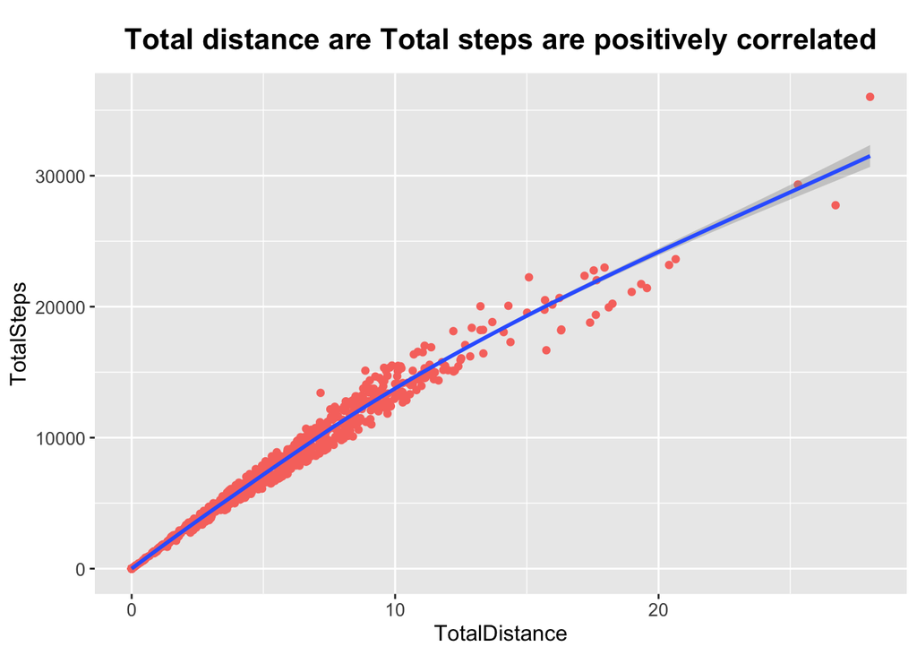

```r
ggplot(data = daily_activity, theme = theme_minimal()) +
  geom_point(mapping = aes(x = TotalDistance, y = TotalSteps, color='dark green')) +
  geom_smooth(mapping = aes(x = TotalDistance, y = TotalSteps)) +
  labs(title="Total distance are Total steps are positively correlated", xlab="Total distance (km)", ylab="Total steps") +
  scale_color_discrete(name="Variables", guide = "none") +
  theme(plot.title = element_text(size = 20, hjust = 0.5))+
  theme(plot.title = element_text(face = "bold",
                                  margin = margin(10, 0, 10, 0),
                                  size = 16),
                                  axis.title = element_text(size = 12),
        axis.text = element_text(size = 10))
```

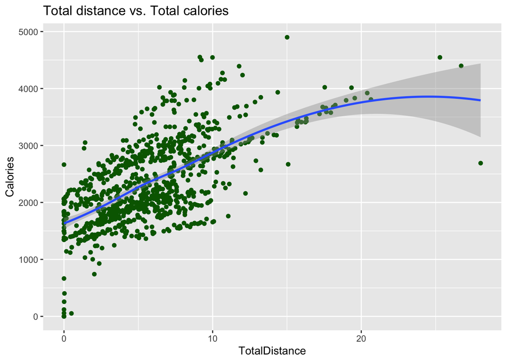

```r
#Again assuming greater distance leads to greater calories burnt
ggplot(data = daily_activity, theme = theme_minimal()) +
  geom_point(mapping = aes(x = TotalDistance, y = Calories), color='dark green') +
  geom_smooth(mapping = aes(x = TotalDistance, y = Calories), method = 'loess', formula = 'y ~ x') +
  labs(title="Total distance vs. Total calories", xlab="Total distance (km)", ylab="Total calories") +
  scale_color_discrete(name="Variables", guide = "none")
```

```r
cor.test(daily_activity$TotalDistance, daily_activity$Calories)
```

```
##
##  Pearson's product-moment correlation
##
## data:  daily_activity$TotalDistance and daily_activity$Calories
## t = 25.848, df = 938, p-value < 2.2e-16
## alternative hypothesis: true correlation is not equal to 0
## 95 percent confidence interval:
##  0.6060120 0.6808264
## sample estimates:
##       cor
## 0.6449619
```

A correlation of 0.6449619 suggests a moderate positive relationship between total distance and total calories. This means that as total distance increases, total calories tend to also increase. However, it is important to note that correlation does not necessarily imply causation, and other factors may be influencing the relationship between these variables.

To further analyze the relationship between total distance and total calories, we will look at a linear regression analysis model.

```r
# Fit a linear regression model to predict total calories from total distance
model <- lm(Calories ~ TotalDistance, data = daily_activity)

# Print a summary of the model
summary(model)
```

```
##
## Call:
## lm(formula = Calories ~ TotalDistance, data = daily_activity)
##
## Residuals:
##      Min       1Q   Median       3Q      Max
## -2273.86  -334.06   -65.19   408.30  1817.57
##
## Coefficients:
##               Estimate Std. Error t value Pr(>|t|)
## (Intercept)   1655.703     30.808   53.74   <2e-16 ***
## TotalDistance  118.022      4.566   25.85   <2e-16 ***
## ---
## Signif. codes:  0 '***' 0.001 '**' 0.01 '*' 0.05 '.' 0.1 ' ' 1
##
## Residual standard error: 549.1 on 938 degrees of freedom
## Multiple R-squared:  0.416,  Adjusted R-squared:  0.4154
## F-statistic: 668.1 on 1 and 938 DF,  p-value: < 2.2e-16
```

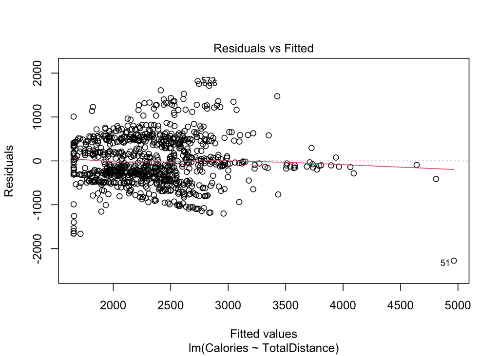

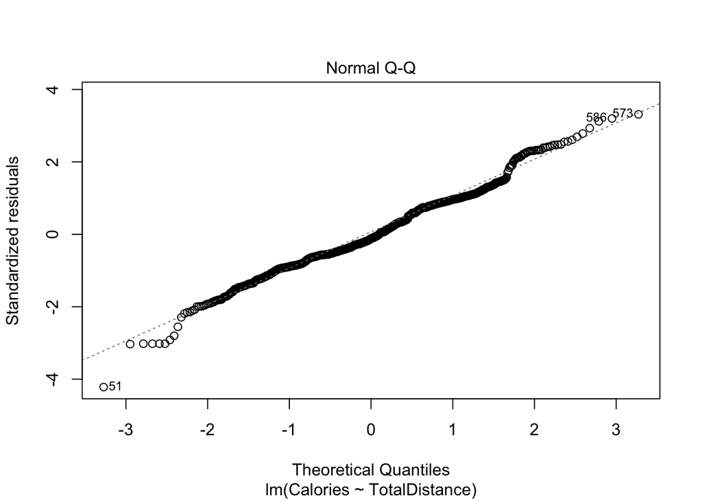

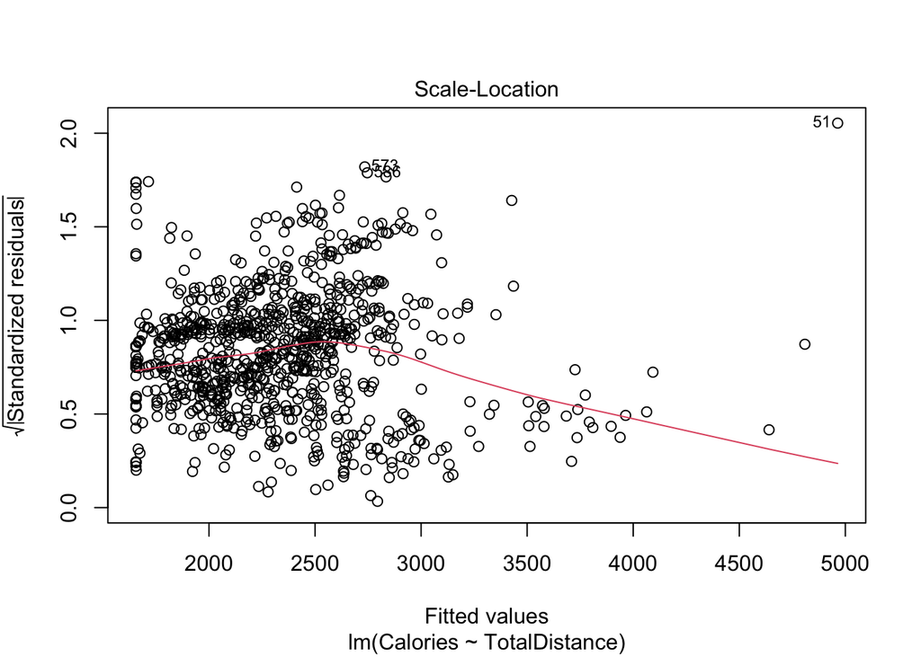

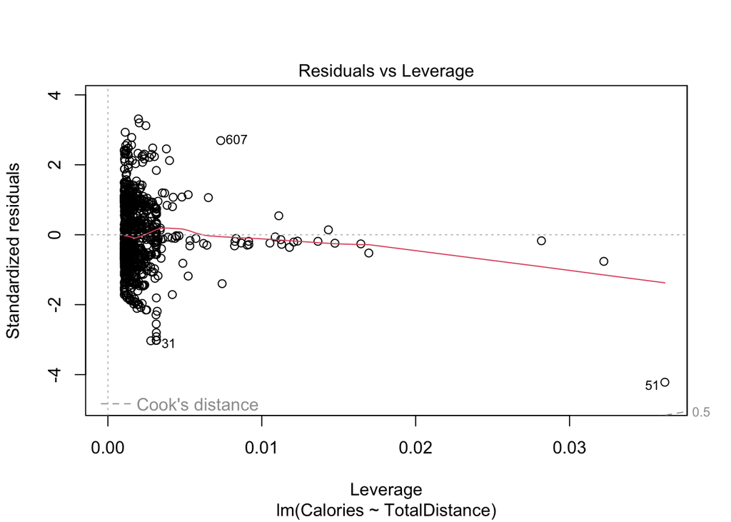

```r
# Create a residual plot
plot(model)
```

Based on the results of the linear regression model, there is a statistically significant relationship between total distance and total calories burned. The model explains 41.6% of the variance in total calories burned. The coefficient for total distance is 118.022, indicating that for every additional kilometer traveled, there is an increase of 118.022 calories burned. This suggests that increasing physical activity, as measured by total distance traveled, is associated with an increase in total calories burned. However, it is important to note that this analysis only considers the relationship between these two variables and does not account for other factors that may influence total calories burned.

#### 4.2 Investigate the correlation between sleep and activity

```r
# Join daily_activity and sleep_day_unique by ActivityDate and SleepDay
merged_data <- left_join(daily_activity, sleep_day_unique, by = c("ActivityDate" = "SleepDay"))

# Fit a linear regression model to predict total steps from sleep duration
model <- lm(TotalSteps ~ TotalMinutesAsleep, data = merged_data)

# Print a summary of the model
summary(model)
```

```
##
## Call:
## lm(formula = TotalSteps ~ TotalMinutesAsleep, data = merged_data)
##
## Residuals:
##     Min      1Q  Median      3Q     Max
## -7860.1 -3851.4  -245.9  3068.3 28447.4
##
## Coefficients:
##                     Estimate Std. Error t value Pr(>|t|)
## (Intercept)        7889.8153   167.1978  47.189   <2e-16 ***
## TotalMinutesAsleep   -0.5116     0.3839  -1.333    0.183
## ---
## Signif. codes:  0 '***' 0.001 '**' 0.01 '*' 0.05 '.' 0.1 ' ' 1
##
## Residual standard error: 5106 on 12533 degrees of freedom
## Multiple R-squared:  0.0001417,  Adjusted R-squared:  6.194e-05
## F-statistic: 1.776 on 1 and 12533 DF,  p-value: 0.1826
```

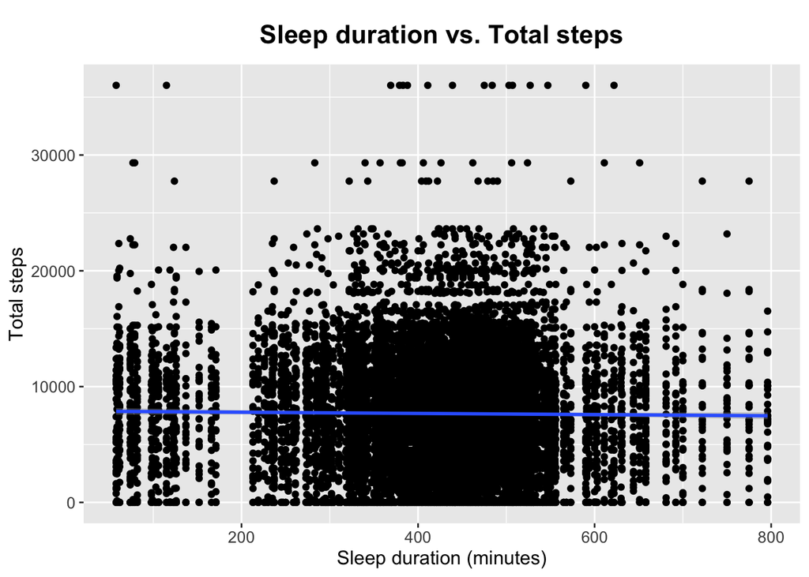

```r
# Create a scatterplot to visualize the relationship between sleep duration and total steps
ggplot(data = merged_data, aes(x = TotalMinutesAsleep, y = TotalSteps)) +
  geom_point() +
  geom_smooth(method = "lm") +
  labs(title = "Sleep duration vs. Total steps", x = "Sleep duration (minutes)", y = "Total steps") +
  theme(plot.title = element_text(size = 20, hjust = 0.5)) +
  theme(plot.title = element_text(face = "bold",
                                  margin = margin(10, 0, 10, 0),
                                  size = 16),
                                  axis.title = element_text(size = 12),
        axis.text = element_text(size = 10))
```

#### Average Steps by Day of the Week

[figure not shown]

```r
 daily_activity <- daily_activity %>%
 mutate(day_of_week = wday(ActivityDate, label = TRUE))
daily_activity_by_day <- daily_activity %>%
  group_by(day_of_week)
daily_activity_by_day <- daily_activity_by_day %>%
  summarize(mean_steps = mean(TotalSteps))


ggplot(data = daily_activity, aes(x = day_of_week, y = TotalSteps, fill = day_of_week)) +
  geom_bar(stat = "identity") +
  xlab("Day of the week") +
  ylab("Mean steps") +
  ggtitle("Mean steps by day of the week") +
  scale_fill_manual(values = c("#0000FF", "#0000FF", "#0000FF", "#0000FF", "#0000FF", "#FF0000", "#FF0000")) +
  theme(legend.position = "none")+
  theme(plot.title = element_text(size = 20, hjust = 0.5)) +
  theme(plot.title = element_text(face = "bold",
                                  margin = margin(10, 0, 10, 0),
                                  size = 16),
                                  axis.title = element_text(size = 12),
        axis.text = element_text(size = 10))
```

```r
# Use kable to create a table with the average number of steps per day
kable(daily_activity_by_day,
  caption = "Average number of steps per day",
  align = c("l", "r"),
  col.names = c("Day of the week", "Mean steps"))
```

Average number of steps per day

| Day of the week | Mean steps |
| --- | --- |
| Sun | 6933.231 |
| Mon | 7780.867 |
| Tue | 8125.007 |
| Wed | 7559.373 |
| Thu | 7405.837 |
| Fri | 7448.230 |
| Sat | 8152.976 |

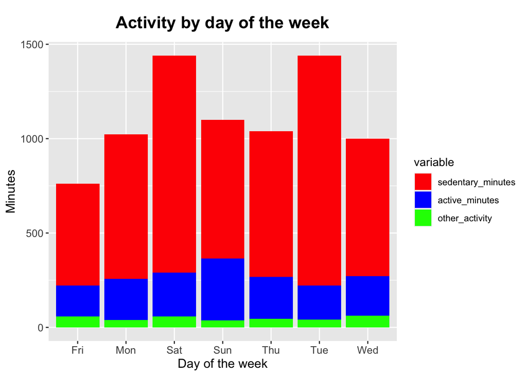

```r
# Create data frame with day of the week, sedentary minutes, active minutes, and other activity categories
activity_data <- data.frame(day_of_week = c("Sun", "Mon", "Tue", "Wed", "Thu", "Fri", "Sat"),
                            sedentary_minutes = c(734, 766, 1217, 727, 773, 539, 1149),
                               active_minutes = c(328, 217, 181, 209, 221, 164, 233),
                            other_activity = c(13 + 25, 19 + 21, 11 + 30, 34 + 29, 10 + 36, 20 + 38, 16 + 42))

# Melt data frame so that each activity category is a separate column
activity_data_melt <- melt(activity_data, id.vars = "day_of_week")

# Create stacked bar chart
ggplot(data = activity_data_melt, aes(x = day_of_week, y = value, fill = variable)) +
  geom_bar(stat = "identity") +
  xlab("Day of the week") +
  ylab("Minutes") +
  ggtitle("Activity by day of the week") +
  scale_fill_manual(values = c("#FF0000", "#0000FF", "#00FF00")) +
  theme(plot.title = element_text(size = 20, hjust = 0.5)) +
  theme(plot.title = element_text(face = "bold",
                                  margin = margin(10, 0, 10, 0),
                                  size = 16),
                                  axis.title = element_text(size = 12),
        axis.text = element_text(size = 10))
```

```r
kable(activity_data, align = "c")
```

| day_of_week | sedentary_minutes | active_minutes | other_activity |
| --- | --- | --- | --- |
| Sun | 734 | 328 | 38 |
| Mon | 766 | 217 | 40 |
| Tue | 1217 | 181 | 41 |
| Wed | 727 | 209 | 63 |
| Thu | 773 | 221 | 46 |
| Fri | 539 | 164 | 58 |
| Sat | 1149 | 233 | 58 |

```r
ggplot(data = activity_counts, aes(x = LoggedActivitiesType, y = n, fill = LoggedActivitiesType)) +
  geom_bar(stat = "identity") +
  labs(title = "Types of activities logged",
       subtitle = "Logging weight is unpopular",
       caption = "Data: FitBit",
       x = "Activity type",
       y = "Count") +
  coord_flip() +
  scale_fill_manual(values = c("#0072B2", "#D55E00", "#CC79A7")) +
  theme(plot.title = element_text(face = "bold",
                                  margin = margin(10, 0, 10, 0),
                                  size = 16),
        plot.subtitle = element_text(size = 12),
        plot.caption = element_text(size = 10),
        legend.title = element_text(size = 12, color = "chocolate", face = 2),
        legend.text = element_text(size = 10),
        axis.title = element_text(size = 12),
        axis.text = element_text(size = 10)) +
  scale_color_discrete("Activity Type:") +
  guides(color = guide_legend(override.aes = list(size = 6)))
```

[output not shown]

#### 4.5 Daily steps

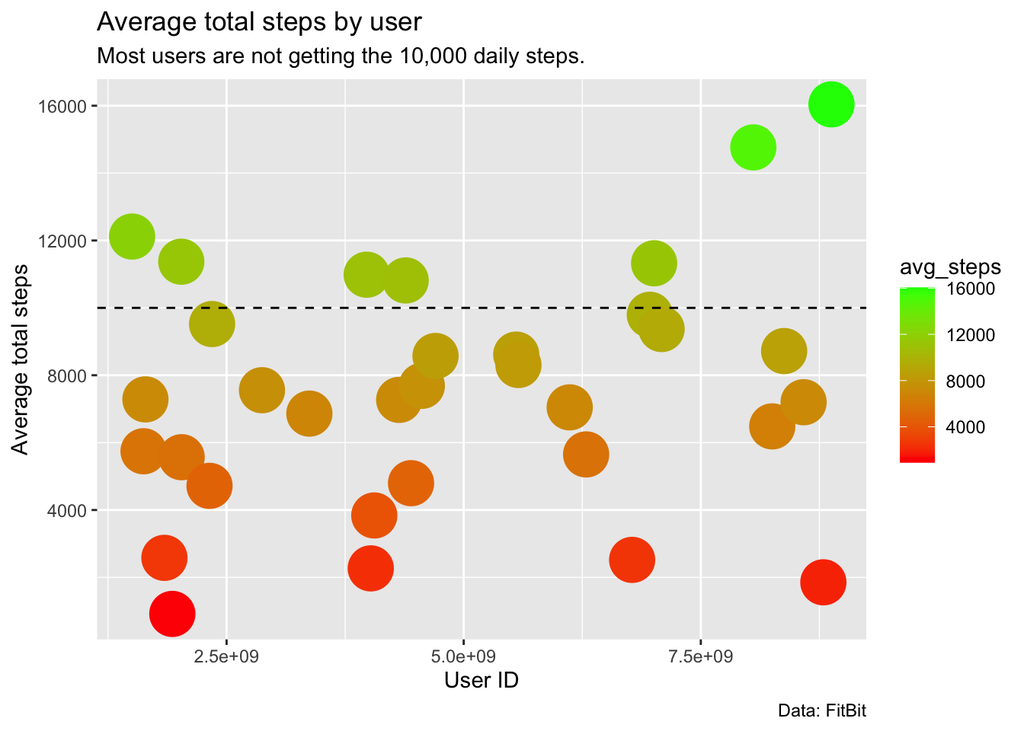

```r
# Calculate the average total steps for each user
avg_steps_by_user <- daily_activity %>%
  group_by(Id) %>%
  summarize(avg_steps = mean(TotalSteps))

# Create the scatter plot
ggplot(data = avg_steps_by_user, aes(x = Id, y = avg_steps, color = avg_steps)) +
  geom_point(size=10) +
  geom_hline(yintercept = 10000, linetype = "dashed") +
  labs(title = "Average total steps by user",
       subtitle = "Most users are not getting the 10,000 daily steps.",
       x = "User ID",
       y = "Average total steps",
       caption = "Data: FitBit") +
  scale_color_gradient(low = "red", high = "green")
```

#### 4.6 Avg no. of users who do not get the required steps

```r
# Calculate the percentage of users who do not get 10000 steps
print(percent_below_10000 <- avg_steps_by_user %>%
  filter(avg_steps < 10000) %>%
  nrow() / nrow(avg_steps_by_user) * 100)
```

```
## [1] 78.78788
```

Perhaps there is a difference in the day of the week that they are more more active. let us explore how Total Steps by day measures up to the 10,000 principal.

```r
daily_activity <- daily_activity %>%
  mutate(day_of_week = wday(ActivityDate, label = TRUE))

ggplot(data = daily_activity, aes(x = day_of_week, y = TotalSteps, fill = day_of_week)) +
  geom_bar(stat = "identity") +
  theme(legend.position = "none") +
  xlab("Day of the week") +
  ylab("Total steps") +
  ggtitle("Total steps by day of the week") +
  scale_fill_manual(values = c("#0000FF", "#0000FF", "#0000FF", "#0000FF", "#0000FF", "#FF0000", "#FF0000"))
```

[output not shown]

These insights suggest that there may be an opportunity for Bellabeat to promote their products as a way to help users reach their daily step goal, especially on days with lower activity levels. This could potentially lead to increased engagement with their products and improve the overall health outcomes of their customers.

## 5 Act

#### 5.1 Overall conclusion

Through my analysis, I have identified several areas where Bellabeat could focus their efforts to improve the usefulness of their devices in promoting better health. These include promoting regular movement throughout the day, providing more opportunities for users to track and measure their weight, and finding ways to encourage users to take more daily steps.

#### 5.2 Recommendations

**3. Improve how users log weight.** To make it easier for users to track their weight, I recommend that Bellabeat consider partnering with other smart devices such as smart weighing scales. By simplifying the process of weighing oneself and making it more reliable, users will be able to more accurately track their progress and receive tailored recommendations. In combination with a fitness plan, users could also use their weight logs as additional motivation to stay active, as they can see tangible results on their app.

**4. Promote daily sleep** To help users sleep better, I recommend a two-pronged approach. First, if users input their morning alarms through the device, Bellabeat could use push notifications to prompt users to start winding down for bed 8-9 hours before the alarm. Second, research has shown that a consistent sleep routine, as well as reducing caffeine intake 10 hours before sleep, can promote better sleep. Bellabeat could prompt users to meditate or do a simple breathing exercise

In conclusion, the data analyzed in this case study is limited and further data would be needed to make more concrete recommendations. However, my insights provide a valuable starting point for further exploration and have helped identify potential areas for improvement in Bellabeat’s marketing strategy. I have considered the needs and goals of all key stakeholders in completing the business task.

If you have any additional recommendations or questions about this case study, please do not hesitate to contact me directly.